# The Unbearable Lightness of Being

Shuhan Song

3/4/2020

## Milan Kundera and his best-known work

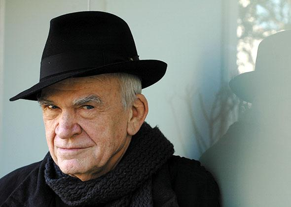

Photo by Catherine Hélie

Milan Kundera was born on April 1, 1929 in Czech. He went into exile in France and became a French citizen in 1981. Kundera sees himself as a French writer and sees his works as French literature. His novels usually go beyond the imaginary characters from his figments to construct his philosophical reflections, especially after the publication of his most famous work, **The Unbearable Lightness of Being**, in 1984. In this book, Kundera challenges German philosipher Friedrich Nietzsche’s idea of eternal recurrence of events and the universe and demostrates a world where everyone only lives once and everything occurs in life only occurs once.

This demonstration created by Kundera is referred to as the “lightness of being”, which signifies freedom for character **Tomas** and **Sabina**, the husband and his lover, but becomes burden for **Tereza**, the wife. Nietzsche’s concept is attached to the believe that one occurrence is not significant in this novel, thus is meaningless to try to make better choices. At the end, the book delivers Kundera’s believe in that making commitment to a beloved one or a beloved subject is in fact meaningful and desirable because it is such commitment that can lead to true happiness.

Tomas begins as a man who has sex with many women but only loves his wife. He believes if he only has one life, “there is no means of testing which decision (in his life) is better, because there is no basis for comparison”. Sabina, his mistress and closest friend, lives an extreme life of “lightness” as she expresses satisfaction in the act of betrayal and struggles against the constraints of puritan ancestry and the Communist Party. Tereza never condemns Tomas for his infidelities but she sees herself as a weaker person in the relationship. Influenced by her mother’s behavior during her childhood, she always views her body as something disgusting and shameful. After she gets tired of her life with Tomas in Zurich, Tereza returns home to Prague with their dog. At this time, Tomas realizes he cannot live without his wife. He begains to believe commiting to Tereza is a better choice than having many lovers as he used to do. Therefore, Tomas and Tereza moves to countryside where Tomas gives up his obessions of work and need for lovers but discovers the real happiness with Tereza.

[figure not shown]

## Text mining

### Wordcloud

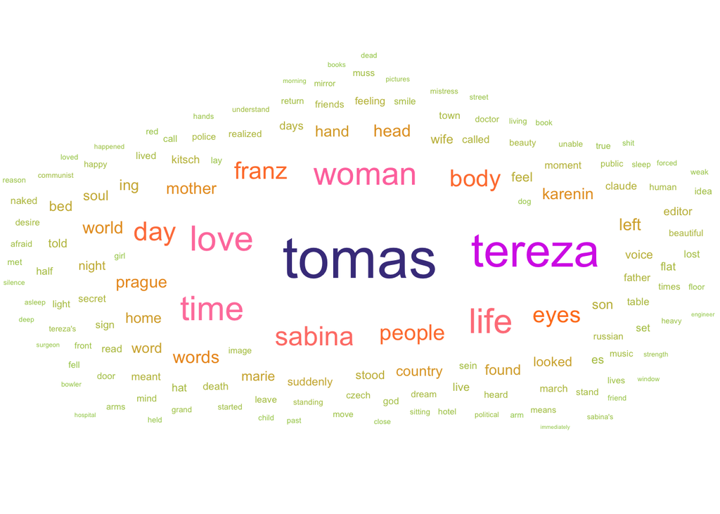

In the wordcloud, Tomas, Tereza, Sabina and Franz (Sabina’s lover) are the main characters. Karenin is the dog of Tomas and Tereza. Other high-frequency words reflect the topics discussed in *The Unbearable Lightness of Being*. Whether **love** is the lightness or burden in **life**? What does a **woman** mean to a man? The influence of **mother** on her daughter and **son**. The relationship between **body** and **soul**.

### Sentimental analysis

#### I. What types of the sentiment are conveyed by the words used by Milan Kundera in *The Unbearable Lightness of Being*?

Comparing the words used by Kundera in his most famous book to the AFINN lexicon list of wording sentiments, there are slightly higher proportion of words with slightly positive sentiments or less negative sentiments (Figure 1). Words associated with more neutral sentiments have higher proportion in *The Unbearable Lightness of Being* than in the lexixon collection.

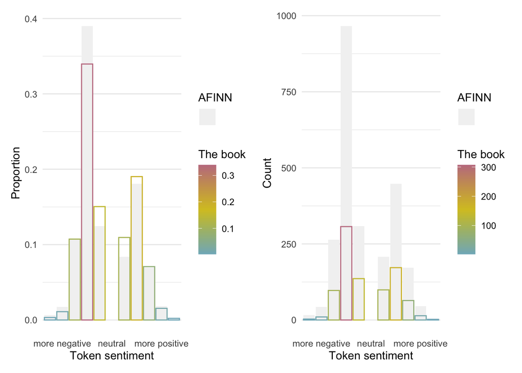

**Figure 1: Word sentiments in the whole collection of AFINN lexicon list vs. in the Kundera’s book.** Light gray bars represent the proportion/count distribution of AFINN lexicon list. Colored bars represent the distribution in *The Unbearable Lightness of Being*.

#### II. What are the words with +4 and +5 sentimental ranks?

Table 1: Most positive words in The Unbearable Lightness of Being

| Word | Postive rank | Times used in the book |
| --- | --- | --- |
| breathtaking | 5 | 1 |
| euphoric | 4 | 1 |
| fantastic | 4 | 1 |
| fun | 4 | 6 |
| funny | 4 | 2 |
| heavenly | 4 | 1 |
| miracle | 4 | 1 |
| overjoyed | 4 | 5 |
| rejoice | 4 | 1 |
| rejoiced | 4 | 1 |
| rejoicing | 4 | 1 |
| stunning | 4 | 2 |
| terrific | 4 | 2 |
| thrilled | 5 | 2 |
| win | 4 | 5 |
| wonderful | 4 | 1 |

#### III. What are the top five popular words in each of the AFINN sentimental bins from rank -3 to 3 in the book?

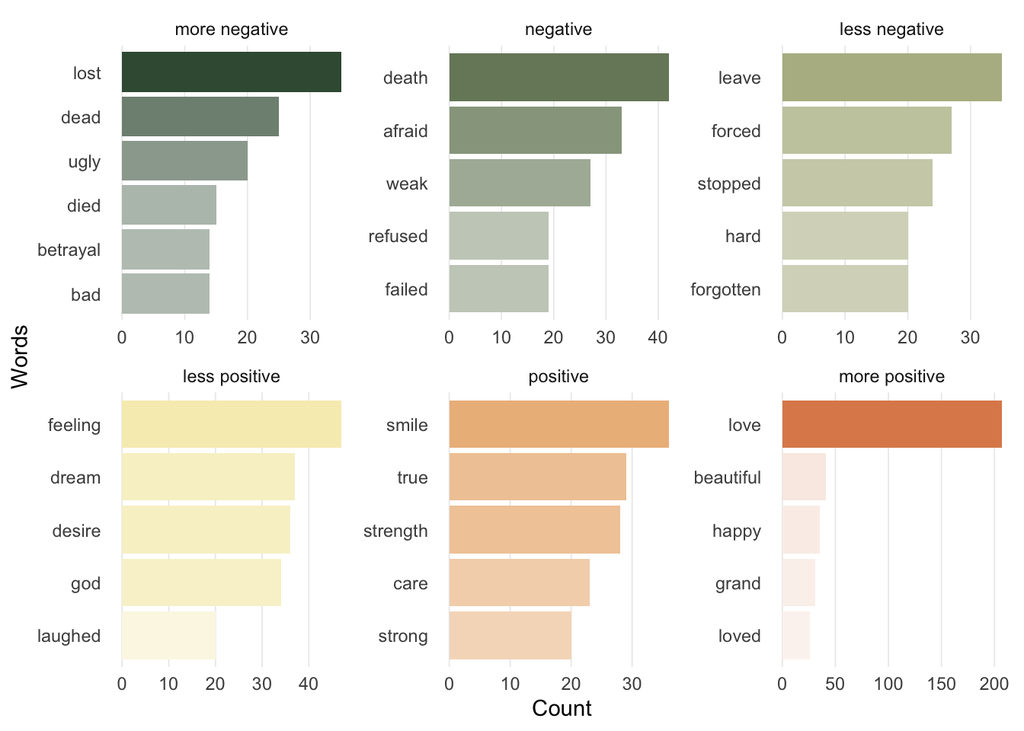

**Figure 2: Top five words in each sentimental bins.** More positive words are colored with warmer colors and more frequent words have higher opacity. The scale of count varied for all six groups. Love is most common in the more positive group (+3) and over all.

#### IV. Not all words in the book are in the AFINN lexicon list

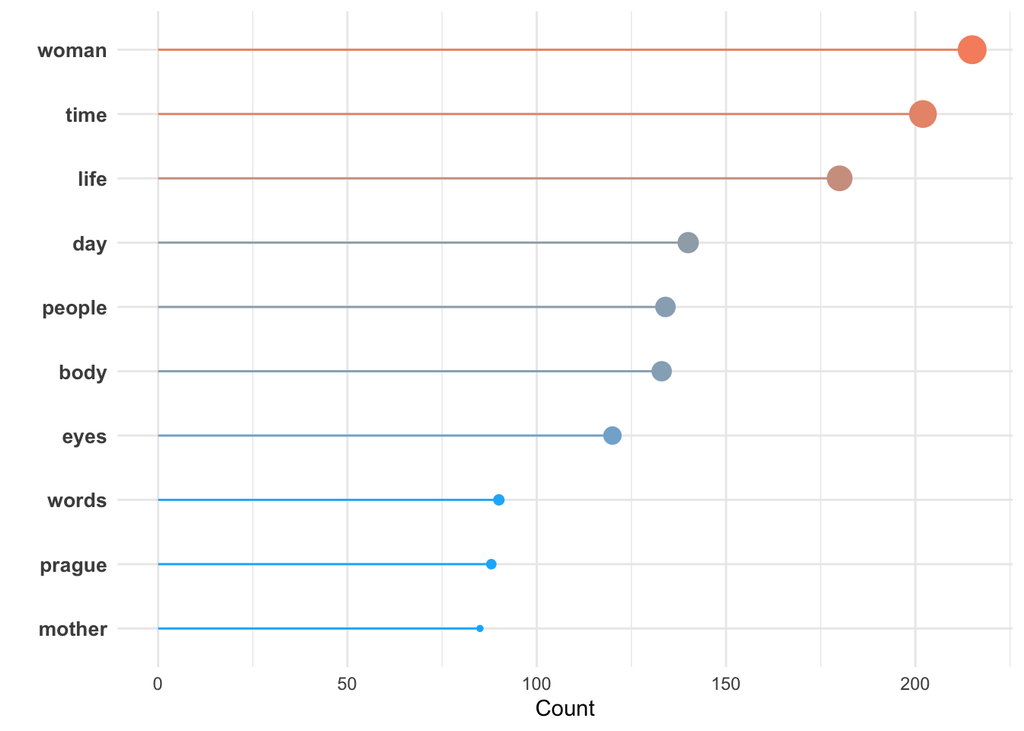

**Figure 3: Common words in the book but not in the AFINN lexicon list.** Most commonly used words are plotted with warmer color and larger bubble size represent higher frequency in the book.

## Reference

Nielsen, F. Å. 2011. A new ANEW: Evaluation of a word list for sentiment analysis in microblogs. CoRR abs/1103.2903.